# Full 18s Community composition

[Some background on Eukaryotic phylogeny](http://tolweb.org/Eukaryotes/3)

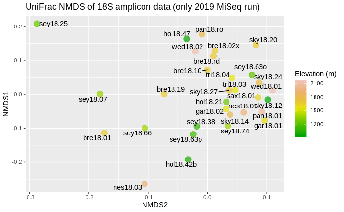

- Seymour samples clustered somewhat, except for sey18.25, sey18.63o
  - sey25 = brevispina, big biofilms
- Hollyburn, 42b close to sey, but 21 and 47 were closer to high elevation samples
- Sky12 closer to high elevation samples despite being from below treeline
- Sax1, gar1, bre1, nes3 outliers from other high elevation samples

Check out sey18.25

| sample_id | asv_id | n_reads | rel_abund | kingdom | phylum | class | order | family | genus | kingdom_conf | phylum_conf | class_conf | order_conf | family_conf | genus_conf | id_level | assignment |
| --- | --- | --- | --- | --- | --- | --- | --- | --- | --- | --- | --- | --- | --- | --- | --- | --- | --- |
| sey18.25 | 011 | 7396 | 2.241756e-01 | Eukaryota | Rotifera | Bdelloidea | Adinetida | NA | NA | 94.78297 | 94.78297 | 94.78297 | 94.78297 | NA | NA | order | Adinetida |
| sey18.25 | 006 | 7332 | 2.222357e-01 | Eukaryota | Basidiomycota | Microbotryomycetes | Kriegeriales | Kriegeriaceae | Kriegeria | 100.00000 | 100.00000 | 97.20600 | 60.52627 | 51.77062 | 51.77062 | genus | Kriegeria |
| sey18.25 | 001 | 4971 | 1.506729e-01 | Eukaryota | Chlorophyta | Chlorophyceae | Chlamydomonadales | Chlamydomonadales | Chloromonas | 100.00000 | 100.00000 | 63.74767 | 58.33551 | 58.33551 | 41.29798 | genus | Chloromonas |
| sey18.25 | 037 | 2426 | 7.353298e-02 | Eukaryota | Chytridiomycota | NA | Rhizophydiales | NA | NA | 100.00000 | 100.00000 | 100.00000 | 97.97081 | NA | NA | order | Rhizophydiales |
| sey18.25 | 035 | 1969 | 5.968113e-02 | Eukaryota | NA | NA | NA | NA | NA | 50.14420 | 50.14420 | NA | NA | NA | NA | kingdom | Eukaryota |
| sey18.25 | 007 | 1391 | 4.216174e-02 | Eukaryota | Basidiomycota | Microbotryomycetes | NA | NA | NA | 100.00000 | 100.00000 | 83.32826 | 83.32826 | NA | NA | class | Microbotryomycetes |
| sey18.25 | 092 | 599 | 1.815592e-02 | Eukaryota | Rotifera | Bdelloidea | Adinetida | NA | NA | 94.60742 | 94.60742 | 94.60742 | 94.60742 | NA | NA | order | Adinetida |
| sey18.25 | 010 | 473 | 1.433681e-02 | Eukaryota | NA | NA | NA | NA | NA | 64.85963 | 64.85963 | NA | NA | NA | NA | kingdom | Eukaryota |
| sey18.25 | 005 | 448 | 1.357905e-02 | Eukaryota | Ciliophora | Intramacronucleata | Conthreep | Oligohymenophorea | Stokesia | 75.67564 | 73.67541 | 73.67541 | 73.07522 | 73.07522 | 71.78140 | genus | Stokesia |
| sey18.25 | 124 | 439 | 1.330626e-02 | Eukaryota | NA | NA | NA | NA | NA | 65.54875 | 65.54875 | NA | NA | NA | NA | kingdom | Eukaryota |

[output cut: 54 more lines]

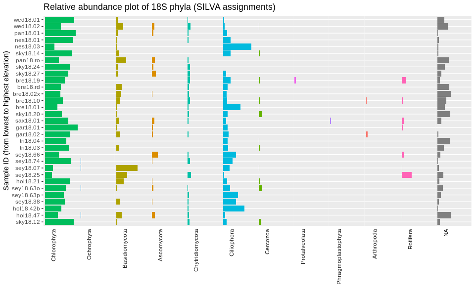

### Chlorophyta

####Trebouxiophyceae

| sample_id | rel_abund |
| --- | --- |
| sax18.01 | 0.3505188710 |
| pan18.01 | 0.0264794035 |
| sky18.27 | 0.0080548660 |
| sky18.24 | 0.0080040020 |
| wed18.02 | 0.0041735367 |
| wed18.01 | 0.0037992832 |
| nes18.01 | 0.0023615937 |
| hol18.47 | 0.0011232569 |
| bre18.19 | 0.0009694485 |
| bre18.02x | 0.0009118195 |

[output cut: 2 more lines]

- sax18.01 outlier, much higher Trebouxiophyceae
  - could explain why an outlier in *rbc*L data?

####Chlorophyceae

| sample_id | rel_abund |
| --- | --- |
| sey18.25 | 0.1825897 |
| sey18.07 | 0.2038328 |
| nes18.03 | 0.2402634 |
| sax18.01 | 0.2448278 |
| bre18.01 | 0.3199926 |
| hol18.47 | 0.3314430 |
| sey18.66 | 0.3490284 |
| pan18.ro | 0.3527452 |
| bre18.02x | 0.3894039 |
| wed18.02 | 0.3925185 |

[output cut: 21 more lines]

- lowest Chlorophyceae is sey18.25, with 18%
- highest " " is gar18.01, with 80%

### Ochrophyta

| sample_id | asv_id | n_reads | rel_abund | kingdom | phylum | class | order | family | genus | kingdom_conf | phylum_conf | class_conf | order_conf | family_conf | genus_conf | id_level | assignment |
| --- | --- | --- | --- | --- | --- | --- | --- | --- | --- | --- | --- | --- | --- | --- | --- | --- | --- |
| sey18.07 | 111 | 507 | 1.707588e-02 | Eukaryota | Ochrophyta | Chrysophyceae | NA | NA | NA | 85.75605 | 85.12453 | 78.29771 | 78.29771 | NA | NA | class | Chrysophyceae |
| hol18.47 | 078 | 485 | 1.328731e-02 | Eukaryota | Ochrophyta | Chrysophyceae | Chrysocapsales | Chrysocapsales | Hydrurus | 100.00000 | 100.00000 | 96.06998 | 89.74522 | 89.74522 | 89.74522 | genus | Hydrurus |
| sey18.74 | 078 | 613 | 1.244392e-02 | Eukaryota | Ochrophyta | Chrysophyceae | Chrysocapsales | Chrysocapsales | Hydrurus | 100.00000 | 100.00000 | 96.06998 | 89.74522 | 89.74522 | 89.74522 | genus | Hydrurus |
| sey18.63o | 071 | 259 | 8.244469e-03 | Eukaryota | Ochrophyta | Chrysophyceae | Chrysocapsales | Chrysocapsales | Hydrurus | 95.84830 | 94.34333 | 90.89713 | 72.68679 | 72.68679 | 72.04157 | genus | Hydrurus |
| tri18.03 | 071 | 190 | 7.380647e-03 | Eukaryota | Ochrophyta | Chrysophyceae | Chrysocapsales | Chrysocapsales | Hydrurus | 95.84830 | 94.34333 | 90.89713 | 72.68679 | 72.68679 | 72.04157 | genus | Hydrurus |
| sky18.24 | 078 | 271 | 6.162172e-03 | Eukaryota | Ochrophyta | Chrysophyceae | Chrysocapsales | Chrysocapsales | Hydrurus | 100.00000 | 100.00000 | 96.06998 | 89.74522 | 89.74522 | 89.74522 | genus | Hydrurus |
| tri18.04 | 071 | 151 | 5.993966e-03 | Eukaryota | Ochrophyta | Chrysophyceae | Chrysocapsales | Chrysocapsales | Hydrurus | 95.84830 | 94.34333 | 90.89713 | 72.68679 | 72.68679 | 72.04157 | genus | Hydrurus |
| sey18.63p | 071 | 332 | 4.905872e-03 | Eukaryota | Ochrophyta | Chrysophyceae | Chrysocapsales | Chrysocapsales | Hydrurus | 95.84830 | 94.34333 | 90.89713 | 72.68679 | 72.68679 | 72.04157 | genus | Hydrurus |
| bre18.10 | 071 | 120 | 3.959612e-03 | Eukaryota | Ochrophyta | Chrysophyceae | Chrysocapsales | Chrysocapsales | Hydrurus | 95.84830 | 94.34333 | 90.89713 | 72.68679 | 72.68679 | 72.04157 | genus | Hydrurus |
| bre18.19 | 111 | 140 | 3.877794e-03 | Eukaryota | Ochrophyta | Chrysophyceae | NA | NA | NA | 85.75605 | 85.12453 | 78.29771 | 78.29771 | NA | NA | class | Chrysophyceae |

[output cut: 16 more lines]

### Basidiomycota

| sample_id | asv_id | n_reads | rel_abund | kingdom | phylum | class | order | family | genus | kingdom_conf | phylum_conf | class_conf | order_conf | family_conf | genus_conf | id_level | assignment |
| --- | --- | --- | --- | --- | --- | --- | --- | --- | --- | --- | --- | --- | --- | --- | --- | --- | --- |
| sey18.07 | 006 | 14547 | 0.4899464484 | Eukaryota | Basidiomycota | Microbotryomycetes | Kriegeriales | Kriegeriaceae | Kriegeria | 100.00000 | 100.00000 | 97.20600 | 60.52627 | 51.77062 | 51.77062 | genus | Kriegeria |
| sey18.25 | 006 | 7332 | 0.2222356935 | Eukaryota | Basidiomycota | Microbotryomycetes | Kriegeriales | Kriegeriaceae | Kriegeria | 100.00000 | 100.00000 | 97.20600 | 60.52627 | 51.77062 | 51.77062 | genus | Kriegeria |
| hol18.21 | 014 | 6357 | 0.1365716373 | Eukaryota | Basidiomycota | NA | NA | NA | NA | 93.41042 | 93.41042 | 93.41042 | NA | NA | NA | phylum | Basidiomycota |
| pan18.ro | 007 | 5213 | 0.1198032772 | Eukaryota | Basidiomycota | Microbotryomycetes | NA | NA | NA | 100.00000 | 100.00000 | 83.32826 | 83.32826 | NA | NA | class | Microbotryomycetes |
| hol18.47 | 007 | 4308 | 0.1180241637 | Eukaryota | Basidiomycota | Microbotryomycetes | NA | NA | NA | 100.00000 | 100.00000 | 83.32826 | 83.32826 | NA | NA | class | Microbotryomycetes |
| wed18.02 | 007 | 6733 | 0.1156395988 | Eukaryota | Basidiomycota | Microbotryomycetes | NA | NA | NA | 100.00000 | 100.00000 | 83.32826 | 83.32826 | NA | NA | class | Microbotryomycetes |
| bre18.rd | 007 | 6602 | 0.0973129136 | Eukaryota | Basidiomycota | Microbotryomycetes | NA | NA | NA | 100.00000 | 100.00000 | 83.32826 | 83.32826 | NA | NA | class | Microbotryomycetes |
| pan18.ro | 014 | 4037 | 0.0927768713 | Eukaryota | Basidiomycota | NA | NA | NA | NA | 93.41042 | 93.41042 | 93.41042 | NA | NA | NA | phylum | Basidiomycota |
| gar18.02 | 007 | 3895 | 0.0731688990 | Eukaryota | Basidiomycota | Microbotryomycetes | NA | NA | NA | 100.00000 | 100.00000 | 83.32826 | 83.32826 | NA | NA | class | Microbotryomycetes |
| bre18.02x | 007 | 3651 | 0.0693552677 | Eukaryota | Basidiomycota | Microbotryomycetes | NA | NA | NA | 100.00000 | 100.00000 | 83.32826 | 83.32826 | NA | NA | class | Microbotryomycetes |

[output cut: 101 more lines]

- sey7, sey25, hol21, pan.ro, wed2 have highest fungi
  - pan.ro:
    - once its off the snow, fungi jump in
    - high unknown Euks
- Kriegeriales yeast
- asv7 blast matches a bunch of fungi 100%

### Ascomycota

| sample_id | asv_id | n_reads | rel_abund | kingdom | phylum | class | order | family | genus | kingdom_conf | phylum_conf | class_conf | order_conf | family_conf | genus_conf | id_level | assignment |
| --- | --- | --- | --- | --- | --- | --- | --- | --- | --- | --- | --- | --- | --- | --- | --- | --- | --- |
| sey18.66 | 004 | 6551 | 0.1504662594 | Eukaryota | Ascomycota | Sordariomycetes | Hypocreales | Cordycipitaceae | NA | 100.00000 | 100.00000 | 99.01872 | 86.91086 | 47.42779 | 47.42779 | family | Cordycipitaceae |
| sky18.27 | 004 | 5518 | 0.0985515529 | Eukaryota | Ascomycota | Sordariomycetes | Hypocreales | Cordycipitaceae | NA | 100.00000 | 100.00000 | 99.01872 | 86.91086 | 47.42779 | 47.42779 | family | Cordycipitaceae |
| wed18.02 | 004 | 2926 | 0.0502541907 | Eukaryota | Ascomycota | Sordariomycetes | Hypocreales | Cordycipitaceae | NA | 100.00000 | 100.00000 | 99.01872 | 86.91086 | 47.42779 | 47.42779 | family | Cordycipitaceae |
| pan18.ro | 070 | 2072 | 0.0476179533 | Eukaryota | Ascomycota | NA | NA | NA | NA | 87.31656 | 82.64458 | 82.64458 | NA | NA | NA | phylum | Ascomycota |
| sky18.24 | 004 | 1356 | 0.0308335986 | Eukaryota | Ascomycota | Sordariomycetes | Hypocreales | Cordycipitaceae | NA | 100.00000 | 100.00000 | 99.01872 | 86.91086 | 47.42779 | 47.42779 | family | Cordycipitaceae |
| sey18.63o | 004 | 864 | 0.0275027853 | Eukaryota | Ascomycota | Sordariomycetes | Hypocreales | Cordycipitaceae | NA | 100.00000 | 100.00000 | 99.01872 | 86.91086 | 47.42779 | 47.42779 | family | Cordycipitaceae |
| gar18.02 | 004 | 1405 | 0.0263934026 | Eukaryota | Ascomycota | Sordariomycetes | Hypocreales | Cordycipitaceae | NA | 100.00000 | 100.00000 | 99.01872 | 86.91086 | 47.42779 | 47.42779 | family | Cordycipitaceae |
| sax18.01 | 080 | 665 | 0.0219776588 | Eukaryota | Ascomycota | Leotiomycetes | NA | NA | NA | 93.21237 | 93.21237 | 53.80638 | NA | NA | NA | class | Leotiomycetes |
| gar18.01 | 004 | 1548 | 0.0201473306 | Eukaryota | Ascomycota | Sordariomycetes | Hypocreales | Cordycipitaceae | NA | 100.00000 | 100.00000 | 99.01872 | 86.91086 | 47.42779 | 47.42779 | family | Cordycipitaceae |
| sey18.38 | 004 | 909 | 0.0179099184 | Eukaryota | Ascomycota | Sordariomycetes | Hypocreales | Cordycipitaceae | NA | 100.00000 | 100.00000 | 99.01872 | 86.91086 | 47.42779 | 47.42779 | family | Cordycipitaceae |

[output cut: 78 more lines]

- unknown Cordycipitaceae, a family of parasitic fungi
- ASV 4 BLAST 100% *Fusarium*, widely distributed in soil, saprophyta assoc w plants (although Wiki places in a different family, Nectriaceae)

### Chytridiomycota

| sample_id | asv_id | n_reads | rel_abund | kingdom | phylum | class | order | family | genus | kingdom_conf | phylum_conf | class_conf | order_conf | family_conf | genus_conf | id_level | assignment |
| --- | --- | --- | --- | --- | --- | --- | --- | --- | --- | --- | --- | --- | --- | --- | --- | --- | --- |
| sey18.25 | 037 | 2426 | 0.0735329777 | Eukaryota | Chytridiomycota | NA | Rhizophydiales | NA | NA | 100.00000 | 100.00000 | 100.00000 | 97.97081 | NA | NA | order | Rhizophydiales |
| bre18.10 | 038 | 1485 | 0.0490001980 | Eukaryota | Chytridiomycota | NA | Gromochytriales | Gromochytriaceae | NA | 97.02561 | 94.09449 | 94.09449 | 89.10764 | 89.10764 | NA | family | Gromochytriaceae |
| bre18.19 | 038 | 1703 | 0.0471705952 | Eukaryota | Chytridiomycota | NA | Gromochytriales | Gromochytriaceae | NA | 97.02561 | 94.09449 | 94.09449 | 89.10764 | 89.10764 | NA | family | Gromochytriaceae |
| wed18.02 | 023 | 2442 | 0.0419414674 | Eukaryota | Chytridiomycota | NA | Rhizophydiales | NA | NA | 95.90568 | 94.33854 | 90.94408 | 86.16172 | NA | NA | order | Rhizophydiales |
| sey18.74 | 032 | 1748 | 0.0354844603 | Eukaryota | Chytridiomycota | NA | Gromochytriales | Gromochytriaceae | NA | 93.19960 | 88.58294 | 88.58294 | 84.45252 | 84.45252 | NA | family | Gromochytriaceae |
| sky18.24 | 023 | 1453 | 0.0330392469 | Eukaryota | Chytridiomycota | NA | Rhizophydiales | NA | NA | 95.90568 | 94.33854 | 90.94408 | 86.16172 | NA | NA | order | Rhizophydiales |
| sky18.20 | 041 | 713 | 0.0327259375 | Eukaryota | Chytridiomycota | NA | Gromochytriales | Gromochytriaceae | NA | 97.00729 | 93.60984 | 93.60984 | 88.86907 | 88.86907 | NA | family | Gromochytriaceae |
| sey18.63p | 032 | 1922 | 0.0284008630 | Eukaryota | Chytridiomycota | NA | Gromochytriales | Gromochytriaceae | NA | 93.19960 | 88.58294 | 88.58294 | 84.45252 | 84.45252 | NA | family | Gromochytriaceae |
| nes18.01 | 041 | 667 | 0.0225026146 | Eukaryota | Chytridiomycota | NA | Gromochytriales | Gromochytriaceae | NA | 97.00729 | 93.60984 | 93.60984 | 88.86907 | 88.86907 | NA | family | Gromochytriaceae |
| sky18.12 | 038 | 536 | 0.0224596690 | Eukaryota | Chytridiomycota | NA | Gromochytriales | Gromochytriaceae | NA | 97.02561 | 94.09449 | 94.09449 | 89.10764 | 89.10764 | NA | family | Gromochytriaceae |

[output cut: 127 more lines]

### Ciliophora:

| sample_id | asv_id | n_reads | rel_abund | kingdom | phylum | class | order | family | genus | kingdom_conf | phylum_conf | class_conf | order_conf | family_conf | genus_conf | id_level | assignment |
| --- | --- | --- | --- | --- | --- | --- | --- | --- | --- | --- | --- | --- | --- | --- | --- | --- | --- |
| hol18.42b | 005 | 27113 | 0.5058112419 | Eukaryota | Ciliophora | Intramacronucleata | Conthreep | Oligohymenophorea | Stokesia | 75.67564 | 73.67541 | 73.67541 | 73.07522 | 73.07522 | 71.78140 | genus | Stokesia |
| nes18.03 | 008 | 17941 | 0.4159170994 | Eukaryota | Ciliophora | Intramacronucleata | Conthreep | Oligohymenophorea | Stokesia | 72.19268 | 70.78798 | 70.78798 | 69.74964 | 69.74964 | 69.26633 | genus | Stokesia |
| sey18.38 | 005 | 14462 | 0.2849430587 | Eukaryota | Ciliophora | Intramacronucleata | Conthreep | Oligohymenophorea | Stokesia | 75.67564 | 73.67541 | 73.67541 | 73.07522 | 73.07522 | 71.78140 | genus | Stokesia |
| sey18.74 | 005 | 11039 | 0.2240920810 | Eukaryota | Ciliophora | Intramacronucleata | Conthreep | Oligohymenophorea | Stokesia | 75.67564 | 73.67541 | 73.67541 | 73.07522 | 73.07522 | 71.78140 | genus | Stokesia |
| bre18.01 | 018 | 7626 | 0.2005311736 | Eukaryota | Ciliophora | Intramacronucleata | Conthreep | Phyllopharyngea | Tokophrya | 76.92835 | 76.45203 | 76.45203 | 76.45203 | 76.45203 | 76.45203 | genus | Tokophrya |
| sey18.63p | 008 | 13211 | 0.1952152969 | Eukaryota | Ciliophora | Intramacronucleata | Conthreep | Oligohymenophorea | Stokesia | 72.19268 | 70.78798 | 70.78798 | 69.74964 | 69.74964 | 69.26633 | genus | Stokesia |
| nes18.03 | 024 | 7348 | 0.1703449555 | Eukaryota | Ciliophora | Intramacronucleata | Spirotrichea | Hypotrichia | NA | 97.36401 | 97.36401 | 97.36401 | 97.36401 | 93.45867 | 93.45867 | family | Hypotrichia |
| sey18.63p | 005 | 10513 | 0.1553476963 | Eukaryota | Ciliophora | Intramacronucleata | Conthreep | Oligohymenophorea | Stokesia | 75.67564 | 73.67541 | 73.67541 | 73.07522 | 73.07522 | 71.78140 | genus | Stokesia |
| sey18.66 | 005 | 6344 | 0.1457117920 | Eukaryota | Ciliophora | Intramacronucleata | Conthreep | Oligohymenophorea | Stokesia | 75.67564 | 73.67541 | 73.67541 | 73.07522 | 73.07522 | 71.78140 | genus | Stokesia |
| gar18.02 | 005 | 7102 | 0.1334134841 | Eukaryota | Ciliophora | Intramacronucleata | Conthreep | Oligohymenophorea | Stokesia | 75.67564 | 73.67541 | 73.67541 | 73.07522 | 73.07522 | 71.78140 | genus | Stokesia |

[output cut: 302 more lines]

- SILVA assigns most to *Stokesia*, but best BLAST match for asv5 is *Frontonia*
- highest in hol18.42b (depth)
  - and nes3, green snow sample

### Cercozoa

| sample_id | asv_id | n_reads | rel_abund | kingdom | phylum | class | order | family | genus | kingdom_conf | phylum_conf | class_conf | order_conf | family_conf | genus_conf | id_level | assignment |
| --- | --- | --- | --- | --- | --- | --- | --- | --- | --- | --- | --- | --- | --- | --- | --- | --- | --- |
| sey18.63o | 017 | 2254 | 7.174916e-02 | Eukaryota | Cercozoa | Glissomonadida | NA | NA | NA | 88.80198 | 88.80198 | 88.80198 | NA | NA | NA | class | Glissomonadida |
| sky18.20 | 017 | 1507 | 6.916969e-02 | Eukaryota | Cercozoa | Glissomonadida | NA | NA | NA | 88.80198 | 88.80198 | 88.80198 | NA | NA | NA | class | Glissomonadida |
| sky18.12 | 017 | 1091 | 4.571548e-02 | Eukaryota | Cercozoa | Glissomonadida | NA | NA | NA | 88.80198 | 88.80198 | 88.80198 | NA | NA | NA | class | Glissomonadida |
| tri18.03 | 017 | 839 | 3.259138e-02 | Eukaryota | Cercozoa | Glissomonadida | NA | NA | NA | 88.80198 | 88.80198 | 88.80198 | NA | NA | NA | class | Glissomonadida |
| bre18.10 | 017 | 552 | 1.821422e-02 | Eukaryota | Cercozoa | Glissomonadida | NA | NA | NA | 88.80198 | 88.80198 | 88.80198 | NA | NA | NA | class | Glissomonadida |
| sky18.14 | 017 | 607 | 1.591088e-02 | Eukaryota | Cercozoa | Glissomonadida | NA | NA | NA | 88.80198 | 88.80198 | 88.80198 | NA | NA | NA | class | Glissomonadida |
| hol18.21 | 017 | 610 | 1.310503e-02 | Eukaryota | Cercozoa | Glissomonadida | NA | NA | NA | 88.80198 | 88.80198 | 88.80198 | NA | NA | NA | class | Glissomonadida |
| bre18.19 | 017 | 417 | 1.155029e-02 | Eukaryota | Cercozoa | Glissomonadida | NA | NA | NA | 88.80198 | 88.80198 | 88.80198 | NA | NA | NA | class | Glissomonadida |
| tri18.04 | 017 | 276 | 1.095586e-02 | Eukaryota | Cercozoa | Glissomonadida | NA | NA | NA | 88.80198 | 88.80198 | 88.80198 | NA | NA | NA | class | Glissomonadida |
| sey18.07 | 017 | 323 | 1.087872e-02 | Eukaryota | Cercozoa | Glissomonadida | NA | NA | NA | 88.80198 | 88.80198 | 88.80198 | NA | NA | NA | class | Glissomonadida |

[output cut: 46 more lines]

- Glissomonads
  - ASV17 BLAST best strain match, 96% *Orciraptor agilis*, a parasite of algae

### Arthropods

| sample_id | asv_id | n_reads | rel_abund | kingdom | phylum | class | order | family | genus | kingdom_conf | phylum_conf | class_conf | order_conf | family_conf | genus_conf | id_level | assignment |
| --- | --- | --- | --- | --- | --- | --- | --- | --- | --- | --- | --- | --- | --- | --- | --- | --- | --- |
| gar18.02 | 050 | 2142 | 0.0402381981 | Eukaryota | Arthropoda | Ellipura | Collembola | NA | NA | 87.74775 | 85.66795 | 84.12660 | 84.12660 | NA | NA | order | Collembola |
| bre18.10 | 050 | 475 | 0.0156734640 | Eukaryota | Arthropoda | Ellipura | Collembola | NA | NA | 87.74775 | 85.66795 | 84.12660 | 84.12660 | NA | NA | order | Collembola |
| tri18.03 | 202 | 262 | 0.0101775240 | Eukaryota | Arthropoda | Ellipura | Collembola | NA | NA | 96.25344 | 95.46379 | 95.46379 | 95.46379 | NA | NA | order | Collembola |
| bre18.10 | 262 | 130 | 0.0042895796 | Eukaryota | Arthropoda | Insecta | Hymenoptera | NA | NA | 92.11094 | 66.76039 | 66.76039 | 62.26650 | NA | NA | order | Hymenoptera |
| gar18.01 | 050 | 203 | 0.0026420595 | Eukaryota | Arthropoda | Ellipura | Collembola | NA | NA | 87.74775 | 85.66795 | 84.12660 | 84.12660 | NA | NA | order | Collembola |
| bre18.01 | 050 | 49 | 0.0012884904 | Eukaryota | Arthropoda | Ellipura | Collembola | NA | NA | 87.74775 | 85.66795 | 84.12660 | 84.12660 | NA | NA | order | Collembola |
| hol18.47 | 397 | 44 | 0.0012054464 | Eukaryota | Arthropoda | Ellipura | Collembola | NA | NA | 98.38536 | 97.57067 | 97.57067 | 97.57067 | NA | NA | order | Collembola |
| gar18.02 | 345 | 64 | 0.0012022618 | Eukaryota | Arthropoda | Ellipura | Collembola | NA | NA | 84.46800 | 81.29791 | 77.67725 | 77.67725 | NA | NA | order | Collembola |
| bre18.rd | 328 | 76 | 0.0011202335 | Eukaryota | Arthropoda | Insecta | NA | NA | NA | 64.96792 | 61.55258 | 61.03040 | 61.03040 | NA | NA | class | Insecta |
| bre18.rd | 050 | 48 | 0.0007075159 | Eukaryota | Arthropoda | Ellipura | Collembola | NA | NA | 87.74775 | 85.66795 | 84.12660 | 84.12660 | NA | NA | order | Collembola |

[output cut: 3 more lines]

- mostly at higher elev red snow sites, and hol47 (which LQ collected, dirty red snow near stream)
- hol47 arthropods are all Collembola, similar to other sites

### Rotifera

| sample_id | asv_id | n_reads | rel_abund | kingdom | phylum | class | order | family | genus | kingdom_conf | phylum_conf | class_conf | order_conf | family_conf | genus_conf | id_level | assignment |
| --- | --- | --- | --- | --- | --- | --- | --- | --- | --- | --- | --- | --- | --- | --- | --- | --- | --- |
| sey18.25 | 011 | 7396 | 0.2241755577 | Eukaryota | Rotifera | Bdelloidea | Adinetida | NA | NA | 94.78297 | 94.78297 | 94.78297 | 94.78297 | NA | NA | order | Adinetida |
| bre18.19 | 011 | 4031 | 0.1116527712 | Eukaryota | Rotifera | Bdelloidea | Adinetida | NA | NA | 94.78297 | 94.78297 | 94.78297 | 94.78297 | NA | NA | order | Adinetida |
| sey18.66 | 011 | 2990 | 0.0686756397 | Eukaryota | Rotifera | Bdelloidea | Adinetida | NA | NA | 94.78297 | 94.78297 | 94.78297 | 94.78297 | NA | NA | order | Adinetida |
| sax18.01 | 011 | 1470 | 0.0485821931 | Eukaryota | Rotifera | Bdelloidea | Adinetida | NA | NA | 94.78297 | 94.78297 | 94.78297 | 94.78297 | NA | NA | order | Adinetida |
| bre18.10 | 011 | 916 | 0.0302250379 | Eukaryota | Rotifera | Bdelloidea | Adinetida | NA | NA | 94.78297 | 94.78297 | 94.78297 | 94.78297 | NA | NA | order | Adinetida |
| gar18.01 | 011 | 1990 | 0.0258999922 | Eukaryota | Rotifera | Bdelloidea | Adinetida | NA | NA | 94.78297 | 94.78297 | 94.78297 | 94.78297 | NA | NA | order | Adinetida |
| sey18.25 | 092 | 599 | 0.0181559166 | Eukaryota | Rotifera | Bdelloidea | Adinetida | NA | NA | 94.60742 | 94.60742 | 94.60742 | 94.60742 | NA | NA | order | Adinetida |
| sey18.07 | 011 | 435 | 0.0146509043 | Eukaryota | Rotifera | Bdelloidea | Adinetida | NA | NA | 94.78297 | 94.78297 | 94.78297 | 94.78297 | NA | NA | order | Adinetida |
| hol18.47 | 011 | 291 | 0.0079723843 | Eukaryota | Rotifera | Bdelloidea | Adinetida | NA | NA | 94.78297 | 94.78297 | 94.78297 | 94.78297 | NA | NA | order | Adinetida |
| bre18.rd | 011 | 445 | 0.0065592618 | Eukaryota | Rotifera | Bdelloidea | Adinetida | NA | NA | 94.78297 | 94.78297 | 94.78297 | 94.78297 | NA | NA | order | Adinetida |

[output cut: 28 more lines]

- sey18.25: highest rotifers, matches photos.
  - could explain why its an outlier in NMDS above

# Check differences between surface and depth samples:

# Check differences in high vs low diversity